# Functional PCA

Michele Gubian

# Overview

## Course overview

- Day 1, 2: uni-dimensional FPCA
- Day 3: multi-dimensional FPCA
- Day 4: landmark registration
- Day 5: UTI? more exercises and examples

## Topics

- Functional PCA (from scratch)
- Landmark Registration (from scratch)
- Linear (Mixed Effects) Regression (assumed)
- GAMMs (optional, for comparison)

## Code

- based on R, `tidyverse`
- recent R libraries: `funData`, `MFPCA`
- based on the older `fda`
- a (work in progress) library written by me: [`landmarkregUtils`](https://github.com/uasolo/landmarkregUtils)
- all available on [this GitHub repo](https://github.com/uasolo/FPCA-phonetics-workshop)

## Applications

- f0 and/or intensity contours
- formants
- multiple articulatory tracks (EMA)
- any time-varying (bundle of) measurement …
- … with or without boundary information

## Examples

- [f0](https://www.prosodylab.linguistics.northwestern.edu/files/2024/06/Cole_Steffman_Awwad_Speech-Prosody_2024.pdf) in Cole, Steffman, and Awwad (2024)
- [f0 and syllable duration](https://repository.ubn.ru.nl/bitstream/handle/2066/303654/303654pub.pdf) in Arvaniti, Katsika, and Hu (2024)
- [f0, F1, F2, CPP, HNR, OQ](https://www.degruyterbrill.com/document/doi/10.1515/phon-2024-0047/html) in Maspong, McCormick, and Kirby (2025)
- [f0 and syllable duration](https://www.sciencedirect.com/science/article/pii/S0167639324000542) and [f0 and intensity](https://www.sciencedirect.com/science/article/pii/S0167639324000542) in El Zarka et al. (2024)
- [Two time-varying acoustic correlates of aspiration](https://www.sciencedirect.com/science/article/pii/S0095447020301078) in Cronenberg et al. (2020)
- [Formants F1 and F2](https://www.isca-archive.org/interspeech_2019/gubian19_interspeech.pdf) in Gubian et al. (2019)
- [EMA sensor trajectory and gesture duration](https://www.isca-archive.org/interspeech_2019/gubian19b_interspeech.pdf) in Gubian, Pastätter, and Pouplier (2019)
- [Cutting down on manual f0 annotation](https://www.isca-archive.org/speechprosody_2016/asano16b_speechprosody.pdf) in Asano, Gubian, and Dominik (2016)
- [Automatic f0 and duration manipulation for resythesis](https://sprosig.org/sp2010/papers/100954.pdf) in Gubian, Cangemi, and Boves (2010)

# Arithmetic with functions

## From time samples to functions

Sampled curve

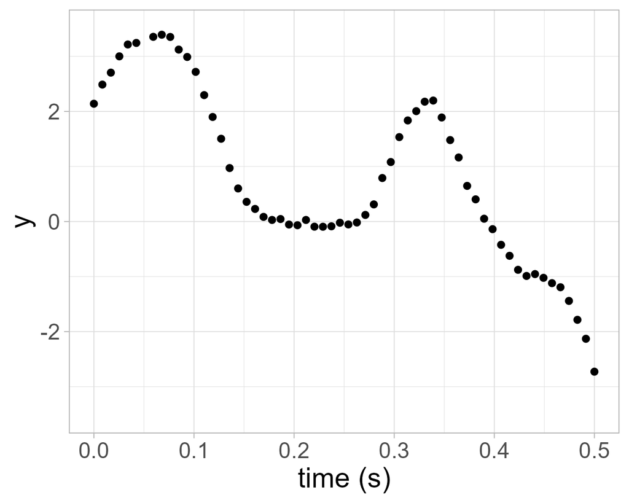

Function $f(t)$

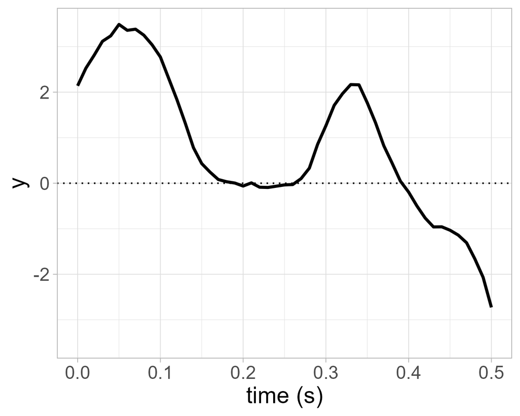

## Addition

$f(t) + \color{red}{g(t)}$

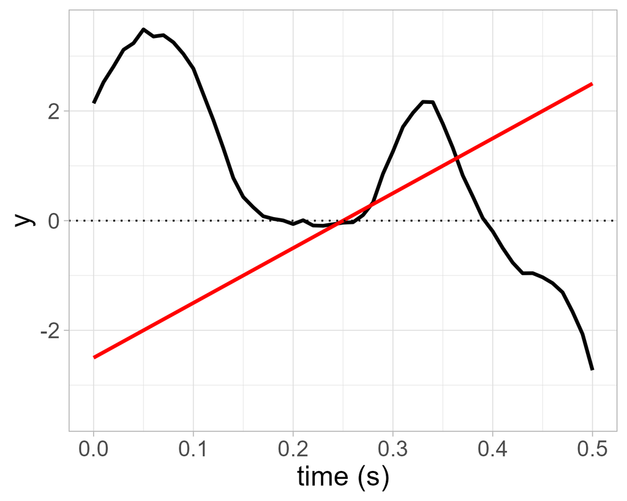

## Addition

$f(t) + \color{red}{g(t)} = \color{blue}{y(t)}$

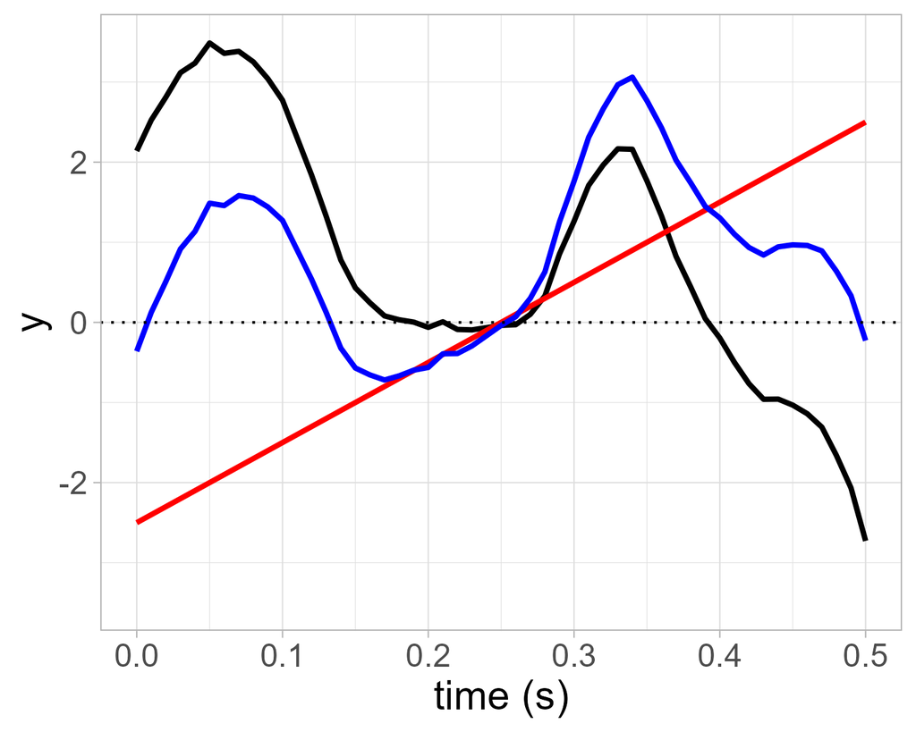

## Multiplication by a scalar

$\color{red}{0.5} \cdot f(t)$

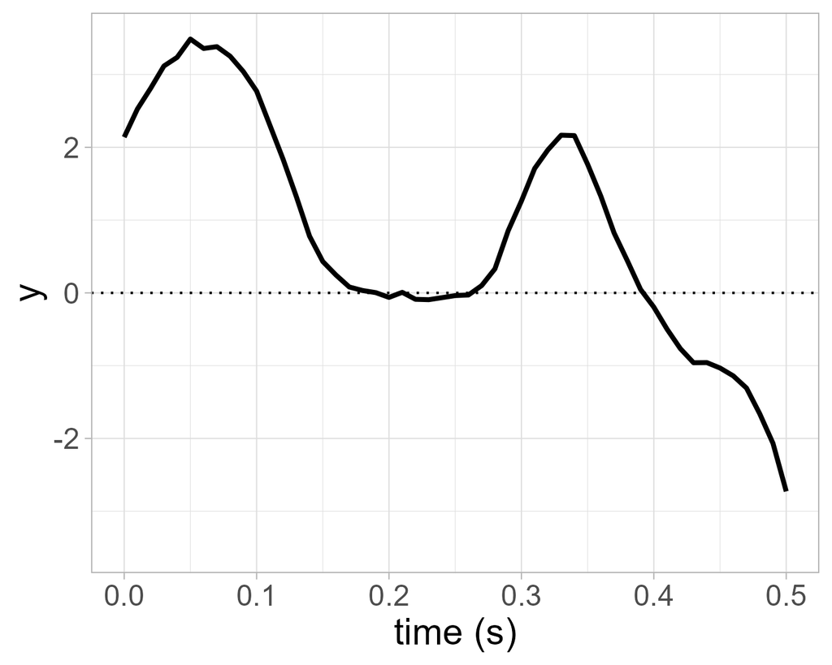

## Multiplication by a scalar

$\color{red}{0.5} \cdot f(t) = \color{blue}{y(t)}$

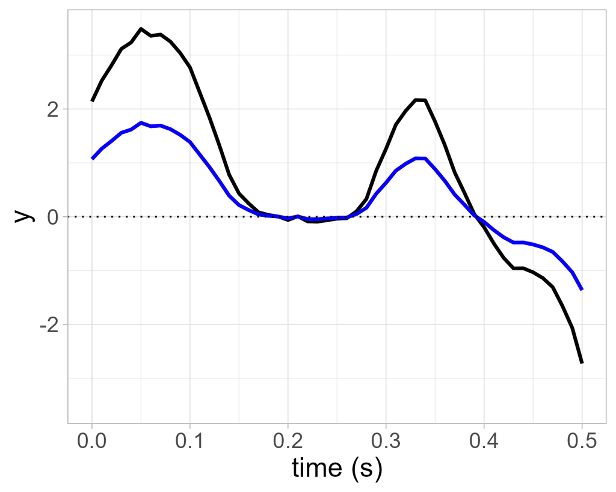

## Multiplication by a scalar

$\color{red}{(-0.5)} \cdot f(t) = \color{blue}{y(t)}$

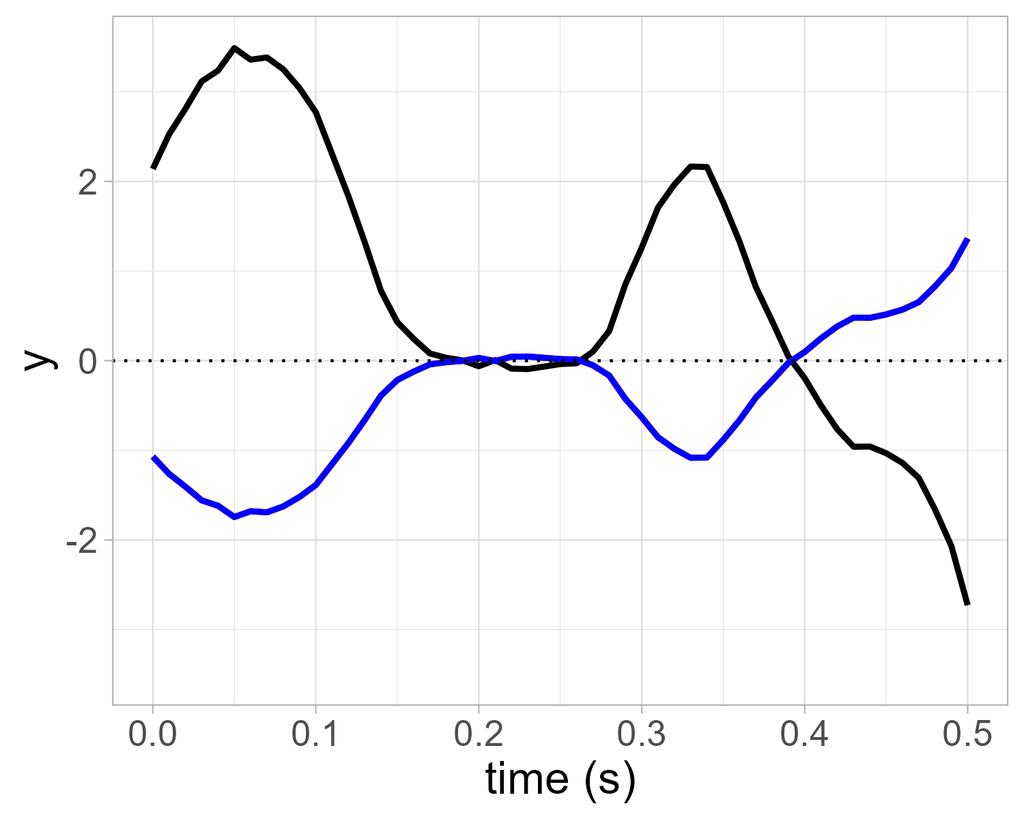

## Mean curve

$\frac{1}{2} \cdot (f(t) + \color{red}{g(t)})$

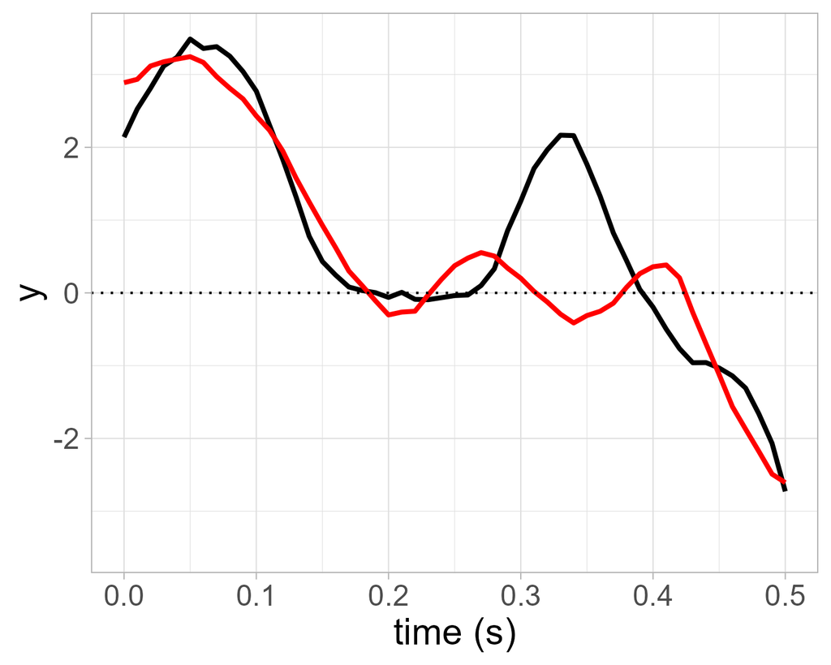

## Mean function

$\frac{1}{2} \cdot (f(t) + \color{red}{g(t)}) = \color{blue}{y(t)}$

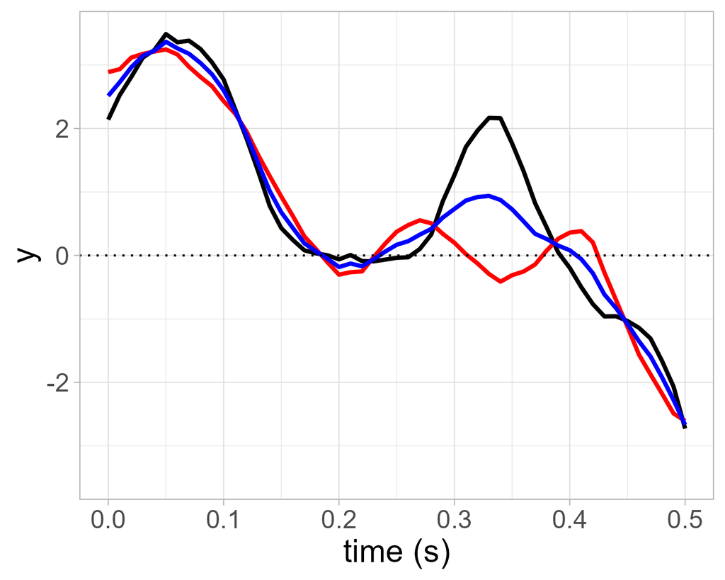

# Uni-dimensional curves

## A curve dataset

100 curves, two categories

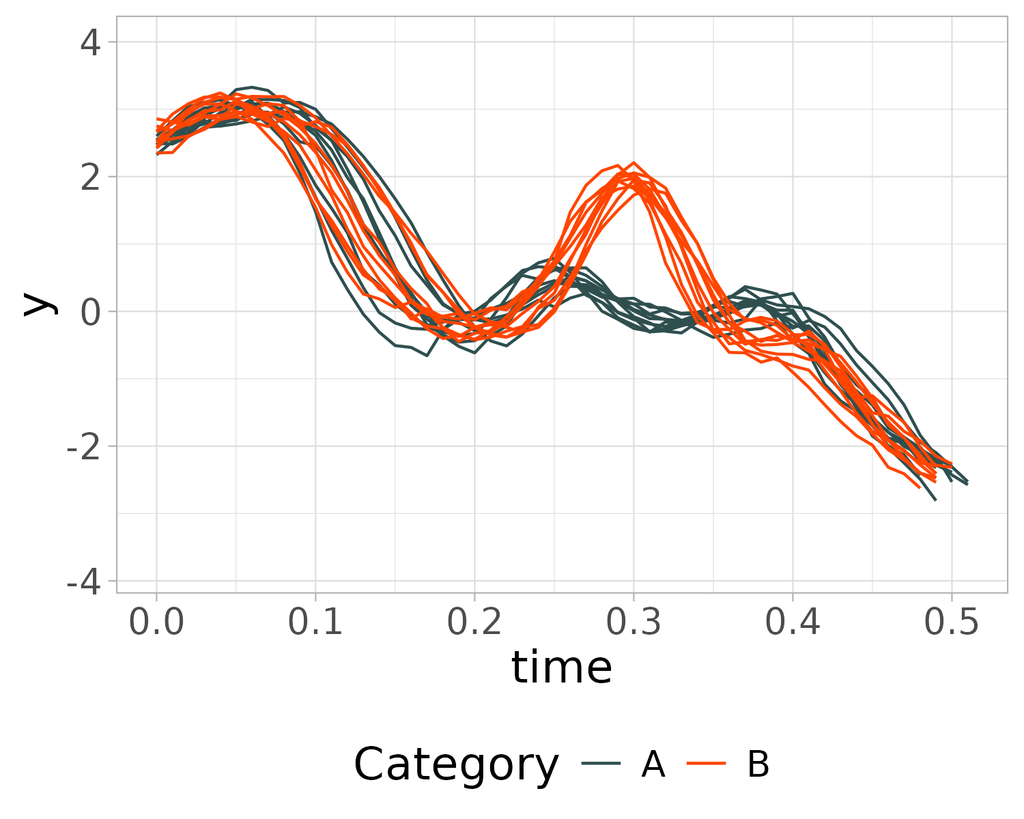

## Procedure overview

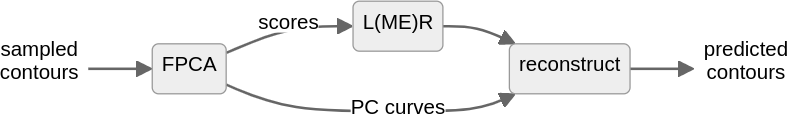

# Functional PCA

## Procedure overview

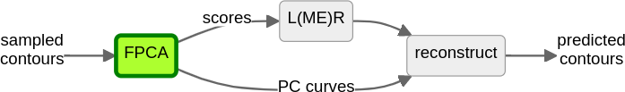

## A curve dataset

100 curves, remove factor information

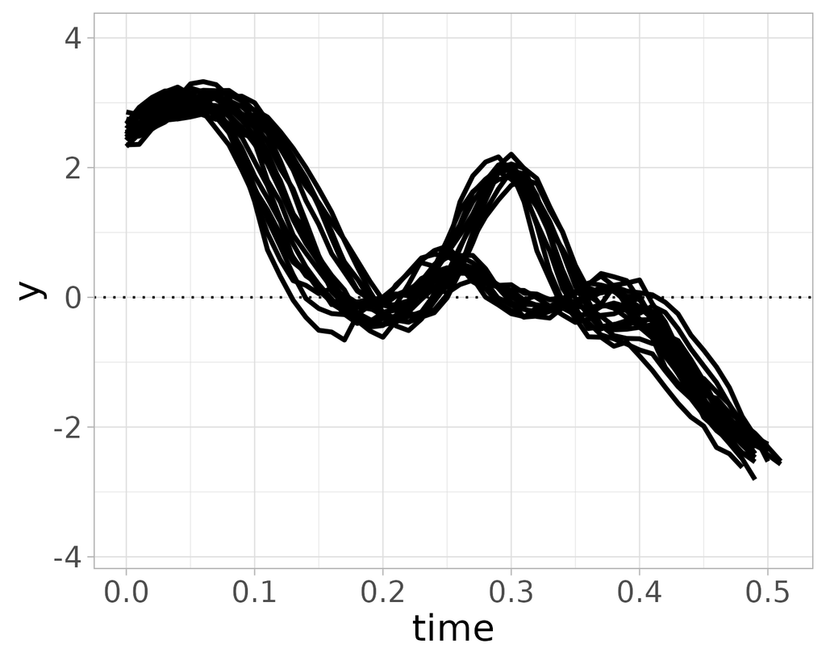

## Subtract mean curve

Mean $\mu(t)$

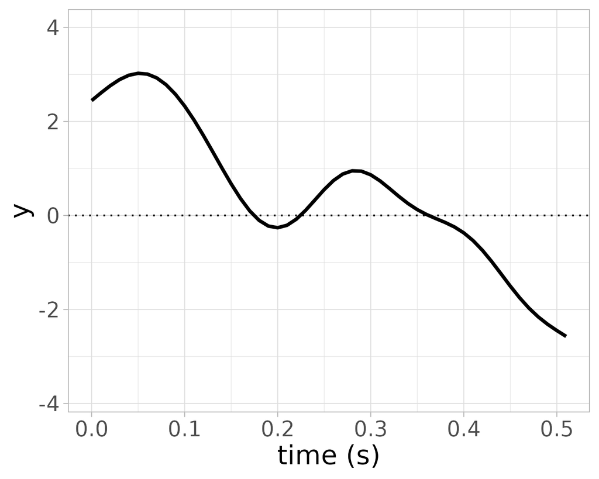

$f_i(t) - \mu(t)$

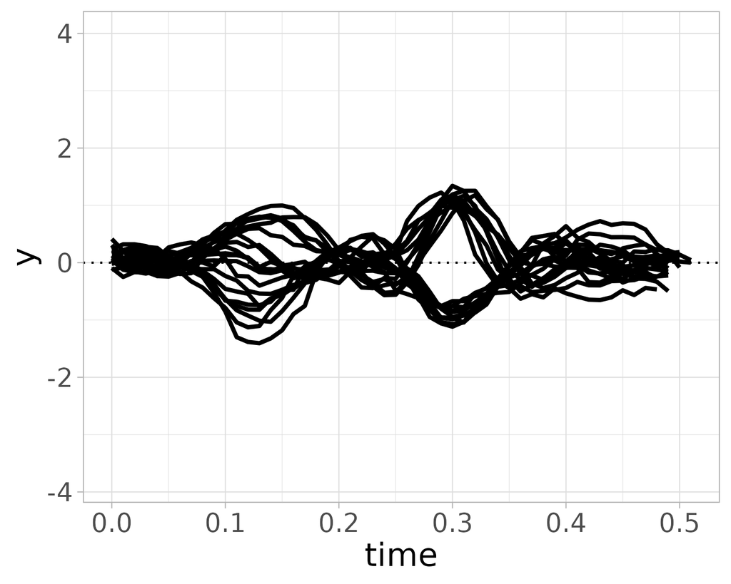

## FPCA outcome

- the mean curve $\mu(t)$
- a number of Principal Component curves, $PC1(t), PC2(t), \cdots$
- a set of corresponding scores, $s_1, s_2, \cdots$ **different for each curve**

## FPC curves

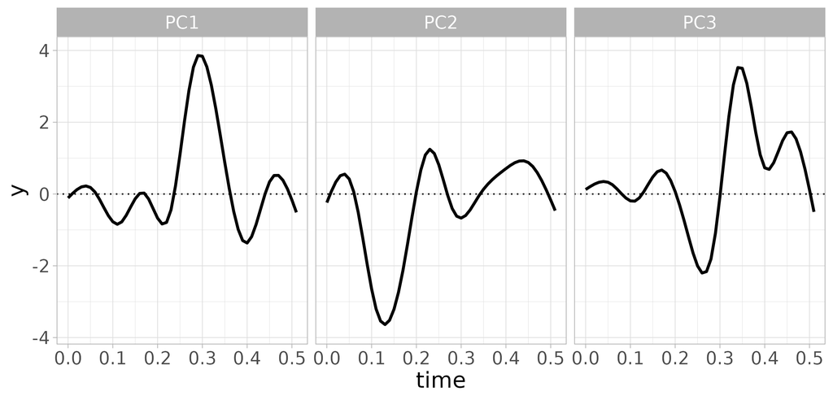

## FPC scores

| curveId | Category | s1 | s2 | s3 |
| --- | --- | --- | --- | --- |
| 1 | A | -0.21 | 0.21 | -0.02 |
| 2 | A | -0.20 | -0.07 | 0.02 |
| 3 | A | -0.15 | 0.16 | 0.00 |
| 51 | B | 0.21 | 0.04 | 0.05 |
| 52 | B | 0.24 | 0.14 | -0.03 |
| 53 | B | 0.27 | 0.17 | 0.06 |

## FPC-based curve reconstruction

$\color{blue}{\hat{f}(t)} = \mu(t)$

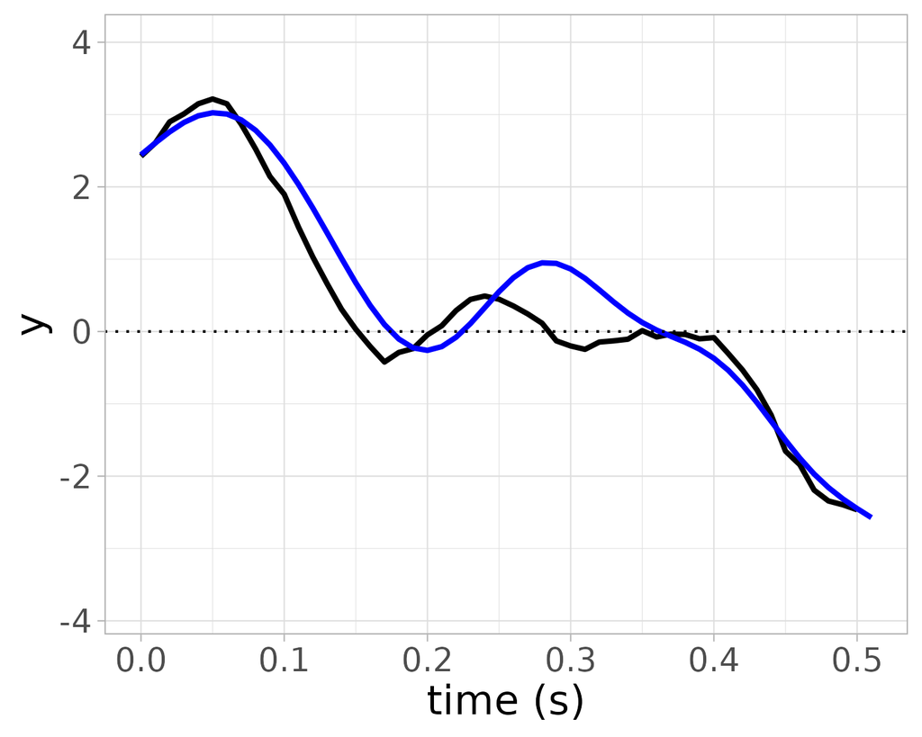

## FPC-based curve reconstruction

$\color{blue}{\hat{f}(t)} = \mu(t) + \color{red}{(-0.21)} \cdot PC1(t)$

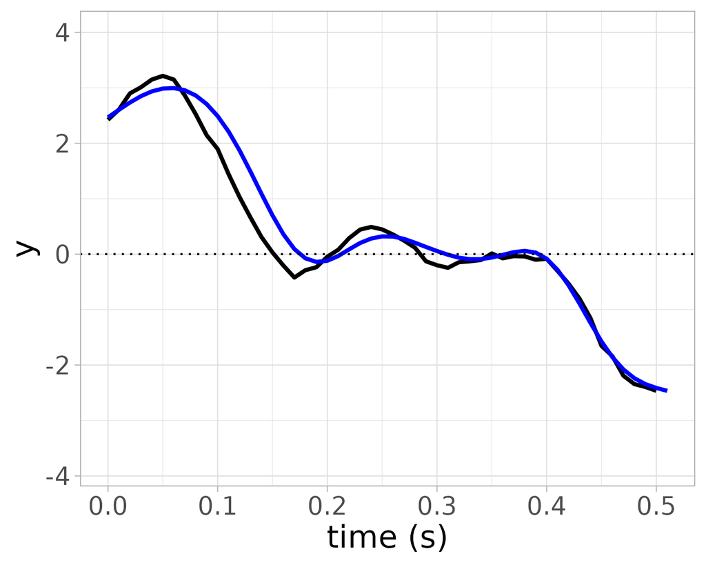

## FPC-based curve reconstruction

$\color{blue}{\hat{f}(t)} = \mu(t) + \color{red}{(-0.21)} \cdot PC1(t) + \color{red}{0.21} \cdot PC2(t)$

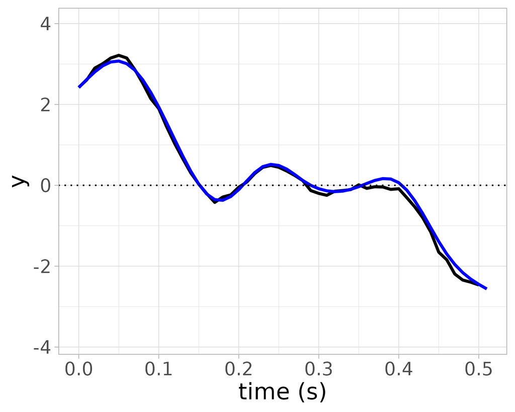

## FPC-based curve reconstruction

$\color{blue}{\hat{f}(t)} = \mu(t) + \color{red}{(-0.21)} \cdot PC1(t) + \color{red}{0.21} \cdot PC2(t) + \color{red}{(-0.02)} \cdot PC3(t)$

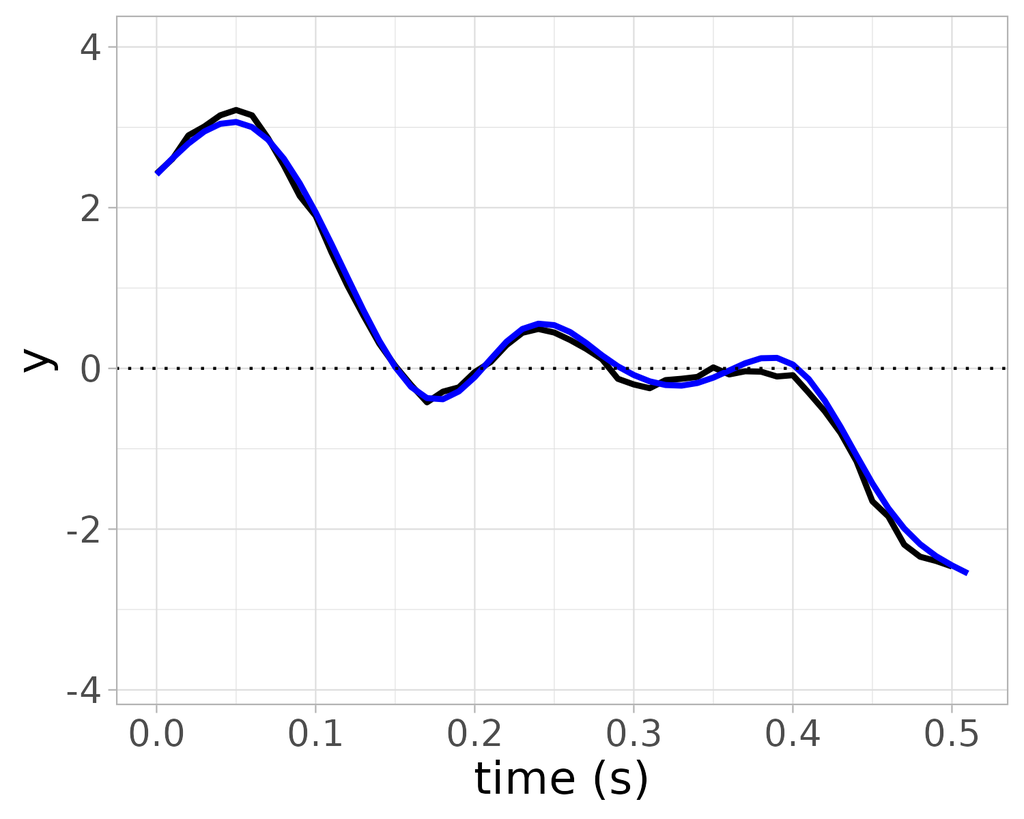

## FPC-based curve reconstruction

$\color{blue}{\hat{f}(t)} = \mu(t)$

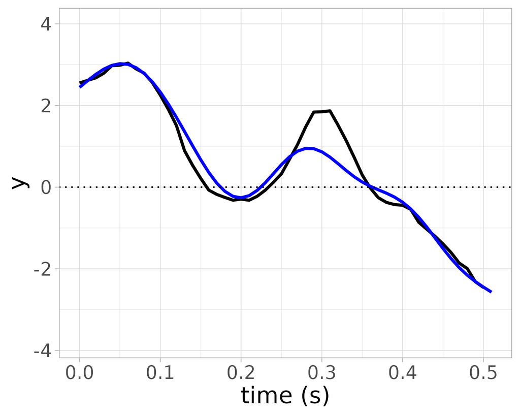

## FPC-based curve reconstruction

$\color{blue}{\hat{f}(t)} = \mu(t) + \color{red}{0.21} \cdot PC1(t)$

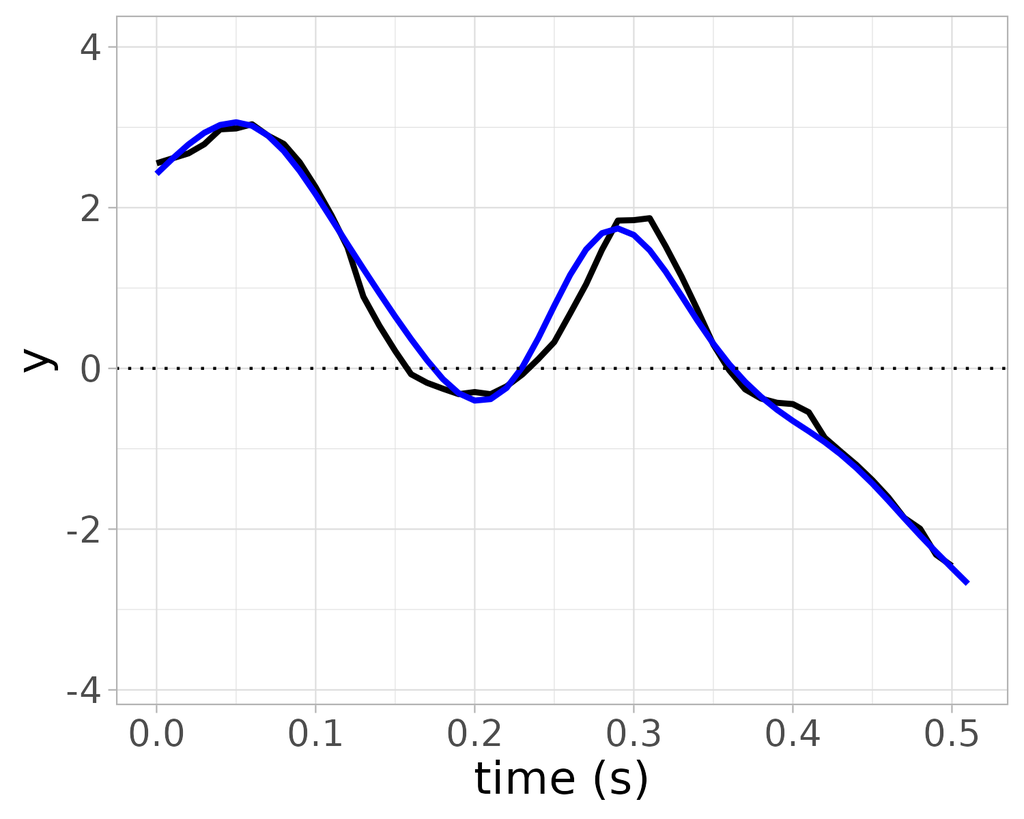

## FPC-based curve reconstruction

$\color{blue}{\hat{f}(t)} = \mu(t) + \color{red}{0.21} \cdot PC1(t) + \color{red}{0.04} \cdot PC2(t)$

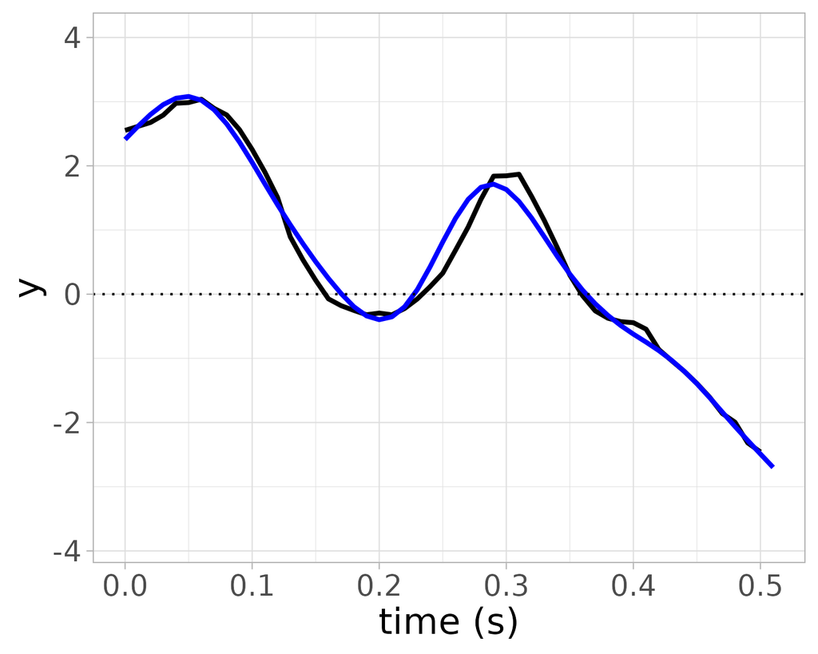

## FPC-based curve reconstruction

$\color{blue}{\hat{f}(t)} = \mu(t) + \color{red}{0.21} \cdot PC1(t) + \color{red}{0.04} \cdot PC2(t) + \color{red}{0.05} \cdot PC3(t)$

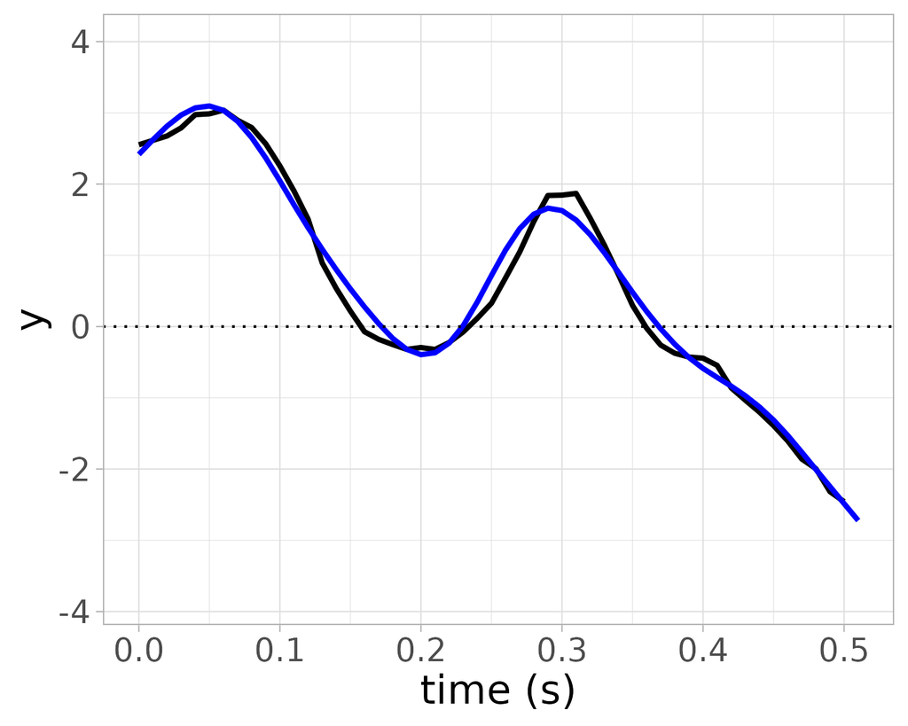

## FPC scores controlling FPC curves

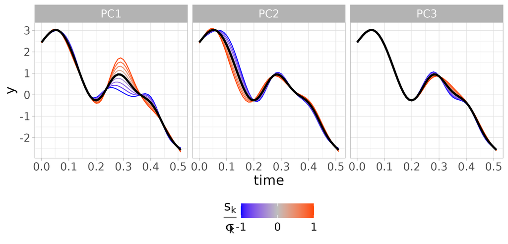

## FPCA summary

- Input curves can be approximated by composing mean curve and PC curves multiplied by respective PC scores
- PC scores are independent, i.e. if we know $s_1$ we cannot guess $s_2$
- All this is true also for other methods, e.g. DCT, Legendre polynomials, growth curves, etc.
- But FPCA constructs PC curves optimised for your dataset, which makes the composition much more compact
- In depth on inner workings of FPCA and other functional decomposition methods in [Day 1 video](https://youtu.be/vVXhmP3FqqE) of the [previous version of this tutorial](https://www.ling.uni-konstanz.de/forschung/workshops/)

## Procedure overview

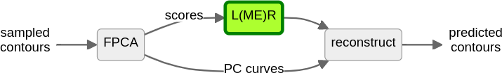

## Reintroduce factors

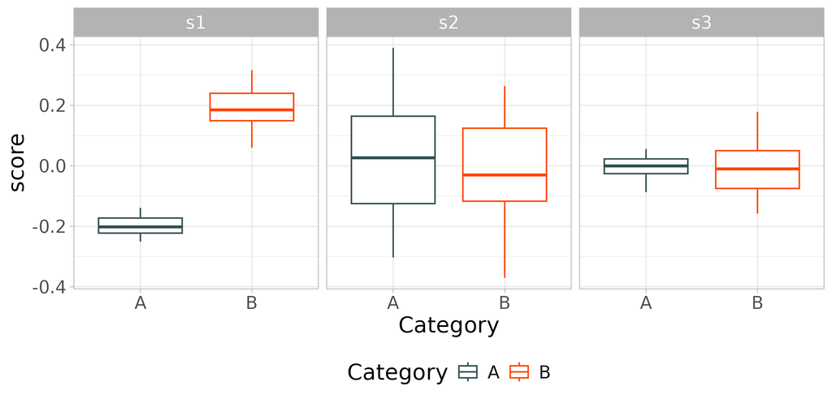

## Fit a regression model on s<sub>1</sub>

```r
mod <- lm(s1 ~ Category, data = PCscores)
summary(mod)
```

```
Call:
lm(formula = s1 ~ Category, data = PCscores)

Residuals:
      Min        1Q    Median        3Q       Max
-0.137063 -0.031294 -0.004309  0.032838  0.119646

Coefficients:
             Estimate Std. Error t value Pr(>|t|)
(Intercept) -0.198269   0.007122  -27.84   <2e-16 ***
CategoryB    0.395197   0.010072   39.24   <2e-16 ***
---
Signif. codes:  0 '***' 0.001 '**' 0.01 '*' 0.05 '.' 0.1 ' ' 1

Residual standard error: 0.05036 on 98 degrees of freedom
Multiple R-squared:  0.9402,    Adjusted R-squared:  0.9395
F-statistic:  1540 on 1 and 98 DF,  p-value: < 2.2e-16
```

## Model predictions on s<sub>1</sub>

```r
library(emmeans)
emmeans(mod, pairwise ~ Category)
```

```
$emmeans
 Category emmean      SE df lower.CL upper.CL
 A        -0.198 0.00712 98   -0.212   -0.184
 B         0.197 0.00712 98    0.183    0.211

Confidence level used: 0.95

$contrasts
 contrast estimate     SE df t.ratio p.value
 A - B      -0.395 0.0101 98 -39.237  <.0001
```

## Procedure overview

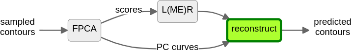

## Reconstruct predicted curves from s<sub>1</sub>

$$f_A(t) = \mu(t) + s_{1, A} \cdot PC1(t)$$
$$f_B(t) = \mu(t) + s_{1, B} \cdot PC1(t)$$

## Reconstruct predicted curves from s<sub>1</sub>

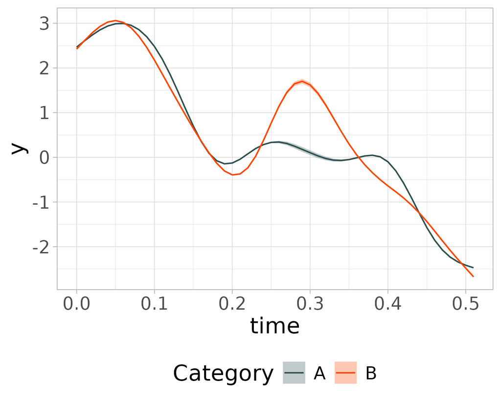

## Outcome

- Compact model of modes of shape variations
- Compact parametrisation of each curve in the dataset
- Regression model predicting curve shapes from factors